# Lexical Scoping

This is **Tutorial 3.2** from the ESL course taught at the Faculty of Informatics and Information Technologies, Slovak University of Technology in Bratislava.

The course loosely follows the book *An* *Introduction to Statistical Learning with Applications in R*[^1], while also drawing inspiration from Hadley Wickham’s *Advanced R*[^2]. You may notice small insights borrowed from these two excellent books here and there because they set a remarkably high standard for beginners, and they’re very hard to surpass.

| Version | Last Edit | Changes |
| --- | --- | --- |
| 2026.1 | 15-2-2026 | Minor text edits. |

This is an optional tutorial designed to help you understand how R works behind the scenes. It’s not required, but it’s strongly recommended if you want to deepen your skills and become more effective in R.

### Motivation

We’ve already discussed left-handed assignment (`<-`), which binds a name to a value. Now, let’s explore scoping, the process of finding the value associated with a name — essentially the counterpart to `<-`.

Understanding scoping rules is essential for comprehending how values are assigned to variables, particularly when working with functions. R uses lexical scoping, also known as static scoping, to determine the value associated with a name.

> The *lexical* in lexical scoping doesn’t correspond to words or the vocabulary of a language as distinguished from its grammar and construction, but comes from the computer science term *lexing*.

Actually, lexing is part of the process that transforms code from text into meaningful components that the programming language can comprehend. Lexical scoping in R is particularly advantageous for statistical computations, as it enables cleaner and more predictable code. This scoping ensures that variable values are located in the environment where the function was defined, not where it is called, thereby preventing unexpected results from variables having different values in various environments.

### Scoping Rules

There are four primary rules in R for lexical scoping: name masking, functions vs variables, a fresh start, and dynamic lookup.

|  | Description |
| --- | --- |
| **Name Masking** | Variable names defined within a function take precedence over names defined outside the function. If a name isn’t found inside a function, R looks one level up in the environment hierarchy. |
| **Functions vs. Variables** | Functions are treated as ordinary objects, and the same scoping rules apply. When a function and a non-function share the same name, the function takes precedence in a function call. |
| **A Fresh Start** | Each function call creates a new environment, meaning the function has no memory of previous runs. Each invocation is independent of the others. |
| **Dynamic Lookup** | R searches for the value of a symbol when the function is executed, not when it is created. This allows for dynamic programming patterns but can make the function less self-contained. |

### Name Masking

The fundamental rule of lexical scoping is that names defined within a function take precedence over names defined outside the function.

```r
x <- 10
f01 <- function() {x <- 20; x}

f01()
```

```
## [1] 20
```

If a name isn’t defined inside a function, R looks one level up and then one level up…

```r
x <- 10
f02 <- function() {y <- 20; c(x,y)}

f02()
```

```
## [1] 10 20
```

The same rules apply when a function is defined within another function. First, R checks the current function. If it doesn’t find the name there, it looks in the environment where that function was defined, continuing this process up to the global environment. Finally, it searches in other loaded packages.

```r
x <- 1
f03 <- function() {
  y <- 2
  i <- function() {
    z <- 3
    c(x, y, z)
  }
  i()
}

f03()
```

```
## [1] 1 2 3
```

Here, a function `f03()` is defined in which, the following occurs:

- A variable `y` is defined and assigned the value `2`.
- A nested function `i` is defined. Inside `i`, the following occurs:
  - A variable `z` is defined and assigned the value `3`.
  - The `c(x, y, z)` function concatenates the values of `x`, `y`, and `z` into a vector.

When you call `f03()`, it executes the following steps:

- Assigns `2` to `y`.
- Defines the nested function `i` and immediately calls it.
- Inside `i`, it assigns `3` to `z` and then evaluates `c(x, y, z)`.
- When evaluating `c(x, y, z)`, R uses lexical scoping to find the values of `x`, `y`, and `z`.
  - `x` is found in the global environment and has the value `1`.
  - `y` is found in the local environment of `f03` and has the value `2`.
  - `z` is found in the local environment of `i` and has the value `3`.

Thus, the call to `i()` returns the vector `c(1, 2, 3)`, and consequently, `f03()` also returns vector `1 2 3`.

### Functions versus Variables

In R, functions are treated as ordinary objects, so the same scoping rules apply to them as well.

```r
f04 <- function(x) x + 1
f05 <- function() {
  f04 <- function(x) x + 100
  f04(10)
}

f05()
```

```
## [1] 110
```

When you call `f05()`, the following happens:

- Inside `f05()`, the local `f04()` function is defined to add `100` to its input.
- The local `f04()` function is then called with `10` as the argument, so it returns `110`.

The final output of calling `f05()` is `110`, demonstrating that the locally defined `f04()` function inside `f05()` takes precedence over the globally defined `f04()` function.

However, when a function and a non-function share the same name (residing in different environments), the scoping rules become more complex. In a function call, R will ignore non-function objects when searching for that name, ensuring the function is correctly identified and executed.

```r
f06 <- function(x) x + 100
f07 <- function() {
  f06 <- 10
  f06(f06)
}

f07()
```

```
## [1] 110
```

### A Fresh Start

What happens to values between function invocations? Consider the example below. What will occur the first time we run this function? What about the second time?

```r
f08 <- function() {
  if (!exists("a")) {
    a <- 1
  } else {
    a <- a + 1
  }
  a
}

f08()
```

```
## [1] 1
```

```r
f08()
```

```
## [1] 1
```

Every time `f08()` is called, it returns the same value. This occurs because a new environment is created for each function call, meaning the function has no memory of previous runs; each invocation is entirely independent. If we break it into subsequent function calls, we will get the following:

The function `f08` does the following:

- It checks if the variable `a` exists in the current environment using the `exists("a")` function.
- If `a` does not exist, it assigns the value `1` to `a`.
- If `a` does exist, it increments the value of `a` by `1`.
- Finally, it returns the value of `a`.

When `f08()` is called for the first time:

- Since `a` does not exist in the current environment, the condition `!exists("a")` evaluates to `TRUE`.
- Therefore, `a` is assigned the value `1`.
- The function returns `1`.

When `f08()` is called again:

- Each function call creates a new environment, so `a` from the previous call does not persist.
- Since `a` still does not exist in the new environment, the condition `!exists("a")` again evaluates to `TRUE`.
- Therefore, `a` is assigned the value `1` again.
- The function returns `1` once more.

### Dynamic Lookup

Lexical scoping determines where to look for values, but not when. R searches for values when the function is executed, not when it is created. This means the function’s output can vary based on objects outside its environment.

It’s generally best to avoid this behavior, as it makes the function less self-contained. This is a common mistake — if you make a typo in your code, you won’t get an error when creating the function, and you might not even get one when running it, depending on the variables defined in the global environment.

### Lazy Evaluation

Lazy evaluation is a strategy where the evaluation of expressions is deferred until their values are actually needed. This approach is particularly beneficial in R, as it enhances efficiency, especially in interactive sessions.

For instance, when a function argument is not used within the function body, R does not evaluate it, thereby saving computational resources.

```r
f09 <- function(x) {10}

f09(stop("This is an error!"))
```

```
## [1] 10
```

Similar behavior can be observed in conditional statements where only the necessary conditions are evaluated, avoiding unnecessary computation of other branches. Lazy evaluation also allows for the creation of infinite data structures without causing infinite loops, as the evaluation is only performed when required. Moreover, R’s lazy evaluation facilitates more efficient memory usage, as only the needed objects are loaded into memory.

### Environments

An environment is a fundamental concept that refers to a collection of objects like functions, variables, and data frames. It’s essentially a space where R stores and manages these objects.

> You can think of the global environment as a bag of names with no implied order, meaning it doesn’t make sense to ask which is the first element in an environment.

When R is started, a global environment is created, which is the top-level environment where user-defined variables and functions reside. Environments are particularly important for function calls, as each function call creates a new environment that helps keep variables local to that function, preventing name clashes and preserving the state of variables throughout the execution of the function.

### Function Environment

When a function is called, it creates its own environment, known as the function environment, which is used for lexical scoping. This is the environment where the code is currently executing.

Let’s use the following code to visualize the function environment in a simple diagram.

```r
x <- 10
f <- function(x) {print(x)}
```

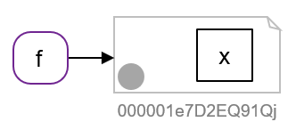

The dot inside the grey rectangle represents the function environment, while the block to the right indicates the function’s argument(s). We won’t illustrate the body, as it can be large and doesn’t aid in understanding the function’s structure. In our case, the function body will contain only one nested function, `print()`, which takes the argument `x`.

### Global Environment

The function name `f` is created in a working environment. When experimenting interactively with R, this is typically the global environment, or `global_env()`. The global environment is where all interactive computations occur.

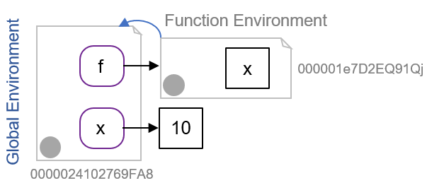

The current environment of `f` is bound to the global environment (indicated by the blue arrow). Since the name `f` resides in the global environment, it is searchable when you type `f` in the Console, as is the value of `x` when used in computations within `f`. Binding the inner environment of `f` to the global environment allows R to implement the scoping rules discussed earlier.

### Parent Environment

The parent environment of `f` is the global environment. In fact, every environment has a parent, another environment. In diagrams, the parent is represented by a blue arrow pointing to a hierarchically higher environment. If a name is not found in an environment, R will search in its parent.

### Summary

Environments are data structures that define the context in which R expressions are evaluated. They contain a collection of symbol-value pairs, where each symbol is associated with a value, and they are organized hierarchically, meaning that each environment has a parent environment (except for the empty environment). This hierarchy is the foundation of R’s scoping rules, which determine how values are searched for when evaluating expressions.

| Function Environment | Global Environment |
| --- | --- |
| When you create a function, it has its own environment. | The global environment, also known as the workspace, is where you define variables, functions, and objects when you’re working interactively. |
| The parent environment of a function is where the function was created. | When you create a variable or function without specifying an environment, it becomes part of the global environment. |
| If you define a function in the global environment, its parent environment is also the global environment. | Variables in the global environment are accessible from any function or script. |
| Inside the function, you can access variables from its parent environment. |  |

### Footnotes

[^1]: James, Gareth, Daniela Witten, Trevor Hastie, and Robert Tibshirani. 2021. *An Introduction to Statistical Learning: With Applications in R*. 2nd ed. New York: Springer.
[^2]: Wickham, Hadley. 2019. *Advanced R*. 2nd ed. Boca Raton, FL: CRC Press.